# Introduction to Model Selection

Aho 2014

A fundamental concern with many analyses is the selection of predictors that provide useful models. One approach is to identify models that are parsimonious, that is, simple but effective. Such an approach utilizes Occam’s Razor to “shave” away predictors from models whose complexity adds little to their explanatory power (Box and Jenkins 1970, Bozdogan 1987). A parsimonious model should:

1. Be based on (be subset from) a set of parameters identified by the investigator as biologically important, including, if necessary, covariates, interactions, and higher-order terms.
2. Have as few parameters as possible (be as simple as possible, but no simpler; Burnham and Anderson 2002, Crawley 2007)

Aside from being philosophically objectionable and difficult to interpret, an overly complex model may simply provide a poor representation of reality due to overfitting. Some texts encourage the use of R<sub>*adj*</sub><sup>2</sup> as a parsimony criterion. This is because, while R<sup>2</sup> will never decrease with the addition of variables, R<sub>*adj*</sub><sup>2</sup> can decrease in this framework.

In simulations comparing 18 model selection algorithms, R<sub>*adj*</sub><sup>2</sup> consistently had the lowest efficiency for situations in which the “true” model belonged to a set of candidate models, and for situations when it did not (McQuarrie and Tsai 1998). Even worse are sources that encourage the use of P-values as a model selection criterion (i.e., choose the simplest model in which P < α).

Akaike (1973) proposed a biased estimator based on a maximized log-likelihood function. An adjusted estimator that accounts for this bias in the form of a penalty term is called the Akaike information criterion or AIC:

$$AIC = -2 \log L + 2p$$
Model comparisons using AIC are often summarized by subtracting the AIC score of the optimal model from the scores of the other candidate models. From the perspective of multimodel inference, the minimum AIC model may not be the “true” best model from a set of candidate models. Table below lists Δ<sub>i</sub> cutoffs defining the support for the *i*th model.

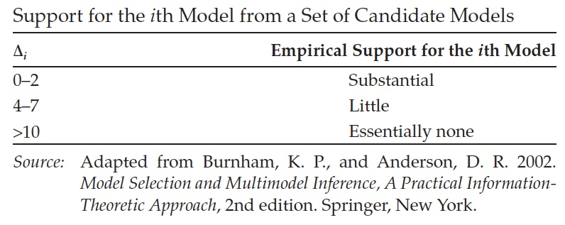

A number of authors have noted that AIC tends to overfit models when sample sizes are small (e.g., Hurvich and Tsai 1980). The second-order “corrected” Akaike information criterion, AIC<sub>c</sub>, is robust to this problem and converges to AIC when n is large.

AIC<sub>c</sub> outperforms other parsimony criteria in a wide variety of model selection situations (McQuarrie and Tsai 1998). Burnham and Anderson (2002) recommend using AICc whenever n/p < 40.

$$AIC_c = AIC+\frac{2k(k+1)}{n-k-1}$$

## Washburn Example (Yellowstone)

https://www.rdocumentation.org/packages/asbio/versions/1.6-7/topics/wash.rich

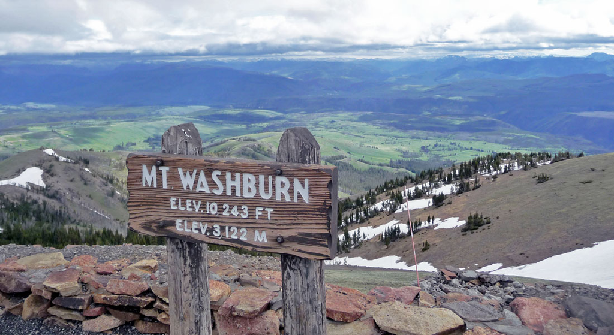

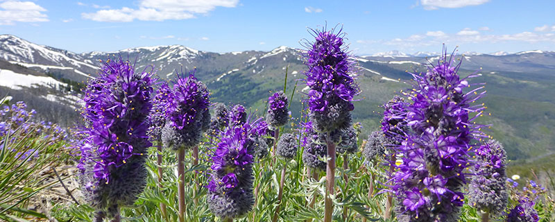

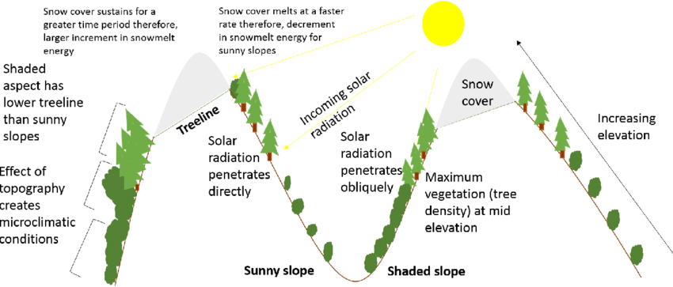

```r
data("wash.rich") #attach data from the asbio library
data_washburn <- rename(wash.rich,
                        site = site,
                        richness = Y,
                        soil_N = X1,
                        slope = X2,
                        aspect = X3,
                        cover = X4, #%surface rock cover
                        pH = X5)
```

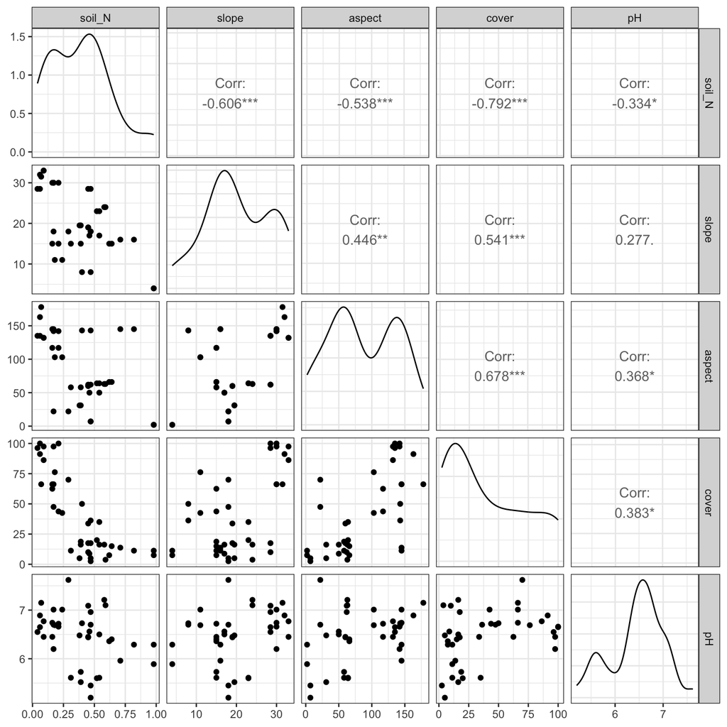

```r
ggpairs(data_washburn, columns = 3:7) + theme_bw()
```

Cover is highly correlated with both soil N and with aspect. This might not be a big deal, but we need to consider to what degree variables are co-linear; to what degree do they inform us about the same phenomenon of interest.

Other people disagree: *“The fact that some or all predictor variables are correlated among themselves does not, in general, inhibit our ability to obtain a good fit nor does it tend to affect inferences about mean responses or predictions of new observations. —Applied Linear Statistical Models, p289, 4th Edition. (Neter, Wasserman, and Kutner)*

However, what we are really concerned with is **multicolinearity**. Multicolinearity is really bad and greatly impacts model interpretation.

```r
model_washburn1 <- lm(richness ~ soil_N + slope + aspect + cover + pH, data=data_washburn)
summary (model_washburn1) #coefficients of the full model
```

```
##
## Call:
## lm(formula = richness ~ soil_N + slope + aspect + cover + pH,
##     data = data_washburn)
##
## Residuals:
##     Min      1Q  Median      3Q     Max
## -9.3079 -2.5606  0.7016  3.0207  6.2828
##
## Coefficients:
##             Estimate Std. Error t value Pr(>|t|)
## (Intercept) 43.96128    9.49284   4.631 5.14e-05 ***
## soil_N      -3.75041    5.00804  -0.749 0.459081
## slope        0.02958    0.11063   0.267 0.790828
## aspect      -0.02423    0.01882  -1.288 0.206439
## cover       -0.15365    0.03948  -3.892 0.000441 ***
## pH          -2.49368    1.39578  -1.787 0.082925 .
## ---
## Signif. codes:  0 '***' 0.001 '**' 0.01 '*' 0.05 '.' 0.1 ' ' 1
##
## Residual standard error: 4.347 on 34 degrees of freedom
## Multiple R-squared:  0.679,  Adjusted R-squared:  0.6318
## F-statistic: 14.38 on 5 and 34 DF,  p-value: 1.394e-07
```

One way of visualizing multicolinearity is by using **Added Variable Plots**. Added Variable Plots (AVPs), sometimes called *partial regression plots*, are diagnostic plots in regression analysis that help you understand the unique contribution of a predictor variable *after accounting for other predictors in the model*. The AVP is essentially like zooming in on just the unique contribution of $X_1$ to $Y$.

**Why two names?**

- “Added-variable” emphasizes the diagnostic use: you’re asking “what happens if I add this variable into the model?” The plot shows the unique contribution of that variable.
- “Partial regression” emphasizes the statistical perspective: you’re looking at the regression of *residual(Y)* on *residual(X)*, which is algebraically equivalent to the partial regression coefficient.

If the plot shows a **strong linear trend**:

- $X_1$ has a strong unique effect on $Y$.

If the plot is **flat or random scatter**:

- $X_1$ does not add much explanatory value after controlling for other predictors.

This allows you to see whether a specific predictor adds meaningful explanatory power beyond the others.

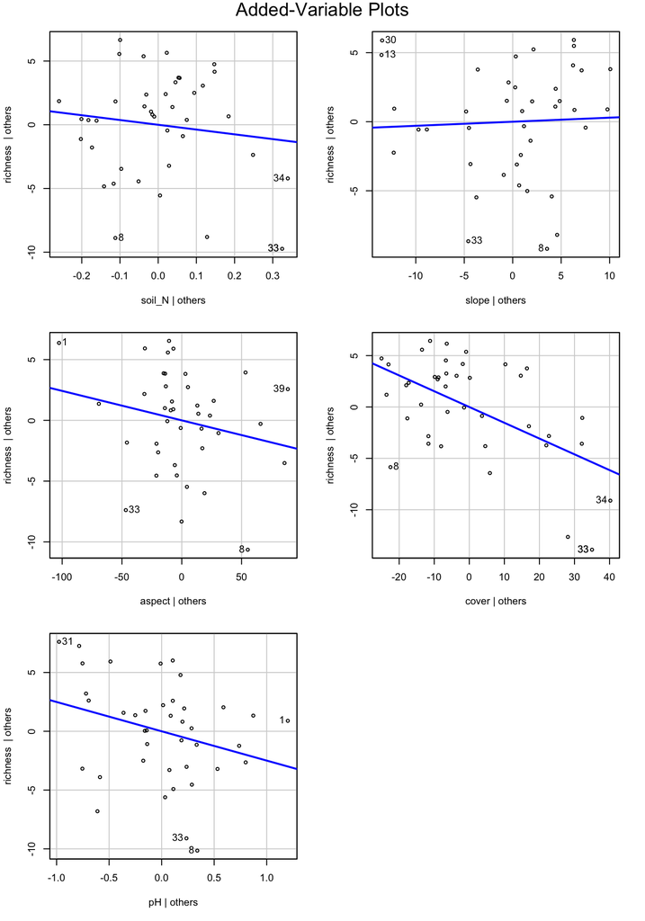

```r
car::avPlots(model_washburn1) #avPlots gives AVPs for many model types including GLMs
```

```r
#olsrr::ols_plot_added_variable(model_washburn1) #only gives AVPs for linear models
```

We can also diagnose multicollinearity using the **Variance Inflation Factor (VIF)**. This measures how much the variance of a regression coefficient is “inflated” because of multicollinearity (correlations among predictors).

```r
performance::check_collinearity(model_washburn1)
```

```
## # Check for Multicollinearity
##
## Low Correlation
##
##    Term  VIF   VIF 95% CI adj. VIF Tolerance Tolerance 95% CI
##  soil_N 3.05 [2.11, 4.79]     1.75      0.33     [0.21, 0.47]
##   slope 1.64 [1.27, 2.54]     1.28      0.61     [0.39, 0.79]
##  aspect 1.93 [1.43, 2.98]     1.39      0.52     [0.34, 0.70]
##   cover 3.57 [2.43, 5.64]     1.89      0.28     [0.18, 0.41]
##      pH 1.21 [1.04, 2.11]     1.10      0.83     [0.47, 0.96]
```

```r
#VIF are also translated to Tolerance values, where tolerance = 1/vif
```

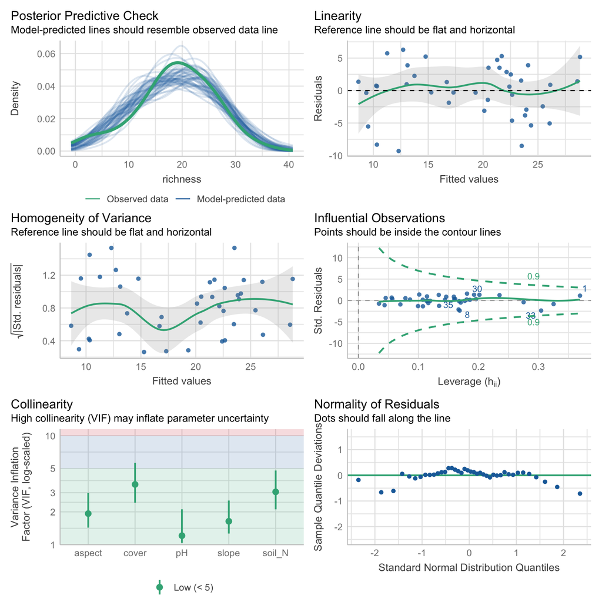

```r
performance::check_model(model_washburn1)
```

**Interpretation of the Variance Inflation Factor**

**VIF = 1** - No correlation with other predictors; the predictor is completely independent.

**VIF between 1 and ~5** - Some correlation with other predictors, but generally not severe. Most researchers consider this acceptable.

**VIF between ~5 and 10** - Indicates moderate to high multicollinearity. Coefficients may be unstable and harder to interpret. You should be cautious and investigate further (e.g., check correlations, consider variable reduction or combining predictors).

**VIF > 10** - Commonly considered a red flag for serious multicollinearity. The predictor is highly redundant with others, and coefficient estimates are likely unreliable (James et al. 2013).

The higher the VIF, the more that predictor’s estimated variance is inflated due to multicollinearity with other predictors. This doesn’t necessarily invalidate your model, but it makes interpreting individual coefficients harder and may reduce statistical power.

Multicollinearity should not be confused with a raw strong correlation between predictors. What matters is the association between one or more predictor variables, *conditional on the other variables in the model*. In a nutshell, **multicollinearity means that once you know the effect of one predictor, the value of knowing the other predictor is rather low**. Thus, one of the predictors doesn’t help much in terms of better understanding the model or predicting the outcome. As a consequence, if multicollinearity is a problem, the model seems to suggest that the predictors in question don’t seems to be reliably associated with the outcome (low estimates, high standard errors), although these predictors actually are strongly associated with the outcome, i.e. indeed might have strong effect (McElreath 2020, chapter 6.1).

“Pairwise correlations are not the problem. It is the conditional associations - not correlations - that matter.” (McElreath 2020, p. 169)

**Multicollinearity and Interaction Terms**  
If interaction terms are included in a model, high VIF values are expected. This portion of multicollinearity among the component terms of an interaction is also called “inessential ill-conditioning”, which leads to inflated VIF values that are typically seen for models with interaction terms (Francoeur 2013).

For demonstration purposes will assume that we have *apriori* justification for including all predictor variables in our model; typically we should cite 1-2 papers supporting the role of each predictor in previous studies. Remember that data dredging is strongly discouraged and can result in spurious (and irrelevant or worse, wrong) results and inference. Our model including all predictor variables was already fit above `model_washburn1`. Use `dredge` function to fit all combinations.

```r
# change na. action
options(na.action = "na.fail") # otherwise blows up with NA values
dredge_washburn <- dredge(model_washburn1)
dredge_washburn
```

```
## Global model call: lm(formula = richness ~ soil_N + slope + aspect + cover + pH,
##     data = data_washburn)
## ---
## Model selection table
##    (Int)      asp     cvr     pH       slp  sol_N df   logLik  AICc delta weight
## 7  42.22          -0.1522 -2.687                   4 -113.695 236.5  0.00  0.212
## 8  41.52 -0.02371 -0.1292 -2.405                   5 -112.791 237.3  0.81  0.141
## 4  26.81 -0.02885 -0.1390                          4 -114.435 238.0  1.48  0.101
## 3  25.54          -0.1692                          3 -115.689 238.0  1.51  0.100
## 23 45.26          -0.1763 -2.754           -4.248  5 -113.243 238.3  1.72  0.090
## 15 41.90          -0.1575 -2.738  0.042340         5 -113.603 239.0  2.44  0.063
## 24 44.53 -0.02361 -0.1532 -2.473           -4.212  6 -112.325 239.2  2.66  0.056
## 16 41.04 -0.02492 -0.1352 -2.460  0.058150         6 -112.611 239.8  3.23  0.042
## 19 27.85          -0.1908                  -3.737  4 -115.372 239.9  3.35  0.040
## 20 29.13 -0.02890 -0.1607                  -3.757  5 -114.093 240.0  3.42  0.038
```

[output cut: 23 more lines]

There are 32 possible models based on additive combinations of variables (no interaction terms).

```r
# grab best supported models
subset(dredge_washburn, delta <5)
```

```
## Global model call: lm(formula = richness ~ soil_N + slope + aspect + cover + pH,
##     data = data_washburn)
## ---
## Model selection table
##    (Int)      asp     cvr     pH     slp  sol_N df   logLik  AICc delta weight
## 7  42.22          -0.1522 -2.687                 4 -113.695 236.5  0.00  0.220
## 8  41.52 -0.02371 -0.1292 -2.405                 5 -112.791 237.3  0.81  0.146
## 4  26.81 -0.02885 -0.1390                        4 -114.435 238.0  1.48  0.105
## 3  25.54          -0.1692                        3 -115.689 238.0  1.51  0.103
## 23 45.26          -0.1763 -2.754         -4.248  5 -113.243 238.3  1.72  0.093
## 15 41.90          -0.1575 -2.738 0.04234         5 -113.603 239.0  2.44  0.065
## 24 44.53 -0.02361 -0.1532 -2.473         -4.212  6 -112.325 239.2  2.66  0.058
## 16 41.04 -0.02492 -0.1352 -2.460 0.05815         6 -112.611 239.8  3.23  0.044
## 19 27.85          -0.1908                -3.737  4 -115.372 239.9  3.35  0.041
## 20 29.13 -0.02890 -0.1607                -3.757  5 -114.093 240.0  3.42  0.040
## 12 26.18 -0.02988 -0.1439        0.04517         5 -114.334 240.4  3.90  0.031
## 11 25.18          -0.1723        0.02398         4 -115.662 240.5  3.93  0.031
## 31 45.04          -0.1768 -2.766 0.01186 -4.063  6 -113.236 241.0  4.48  0.023
## Models ranked by AICc(x)
```

```r
#grab equally competitive models
subset(dredge_washburn, delta <2)
```

```
## Global model call: lm(formula = richness ~ soil_N + slope + aspect + cover + pH,
##     data = data_washburn)
## ---
## Model selection table
##    (Int)      asp     cvr     pH  sol_N df   logLik  AICc delta weight
## 7  42.22          -0.1522 -2.687         4 -113.695 236.5  0.00  0.329
## 8  41.52 -0.02371 -0.1292 -2.405         5 -112.791 237.3  0.81  0.219
## 4  26.81 -0.02885 -0.1390                4 -114.435 238.0  1.48  0.157
## 3  25.54          -0.1692                3 -115.689 238.0  1.51  0.155
## 23 45.26          -0.1763 -2.754 -4.248  5 -113.243 238.3  1.72  0.140
## Models ranked by AICc(x)
```

So there are five models that could be considered equally competitive (having explanatory power that is indistinguishable) But what variables are most influential in our models?

```r
# calculate variable importance weights
sw(dredge_washburn) #notice this is the global model, not just the competitive model set
```

```
##                      cover pH   aspect soil_N slope
## Sum of weights:      1.00  0.64 0.43   0.28   0.22
## N containing models:   16    16   16     16     16
```

**Model averaging is a way to incorporate model selection uncertainty.** Here, the parameter estimates for each candidate model are weighted using their corresponding model weights and summed. There are two methods for model-averaging defined by Burnham and Anderson; where parameter estimates are averaged over all models in which predictor *X<sub>i</sub>* occurs (subset) and where parameter estimates are averaged over all models, not just those in which predictor *X<sub>i</sub>* occurs (full).

http://atyre2.github.io/2017/06/16/rebutting_cade.html

`MuMIn` function `model.avg` conducts both types of model averaging.

```r
# Model average using all candidate models, always use revised.var = TRUE
model.avg(dredge_washburn, revised.var = TRUE)
```

```
##
## Call:
## model.avg(object = dredge_washburn, revised.var = TRUE)
##
## Component models:
## '23'     '123'    '12'     '2'      '235'    '234'    '1235'   '1234'   '25'     '125'
## '124'    '24'     '2345'   '12345'  '245'    '1245'   '135'    '15'     '13'     '1345'
## '134'    '145'    '1'      '14'     '35'     '345'    '5'      '45'     '34'     '3'
## '4'      '(Null)'
##
## Coefficients:
##        (Intercept)      cover        pH      aspect    soil_N       slope
## full       36.9686 -0.1543754 -1.668129 -0.01129341 -1.124111 0.007971148
## subset     36.9686 -0.1544401 -2.604415 -0.02609000 -4.004926 0.036040270
```

Used to average regression coefficients across multiple models with the ultimate goal of capturing a variable’s overall “effect.” https://pubmed.ncbi.nlm.nih.gov/27874997/ https://pubmed.ncbi.nlm.nih.gov/26594695/

Can now report the model averaged coefficients for the predictor variables individual effects on species richness.

```r
#summary(model.avg(dredge_washburn)) # if you want to average across all models, both competitive and non-competitive
summary(model.avg(dredge_washburn, subset = delta < 2)) # if you just want to look only at competitive models, which
```

```
##
## Call:
## model.avg(object = dredge_washburn, subset = delta < 2)
##
## Component model call:
## lm(formula = richness ~ <5 unique rhs>, data = data_washburn)
##
## Component models:
##     df  logLik   AICc delta weight
## 23   4 -113.70 236.53  0.00   0.33
## 123  5 -112.79 237.35  0.81   0.22
## 12   4 -114.43 238.01  1.48   0.16
## 2    3 -115.69 238.05  1.51   0.15
## 234  5 -113.24 238.25  1.72   0.14
##
## Term codes:
## aspect  cover     pH soil_N
##      1      2      3      4
##
## Model-averaged coefficients:
## (full average)
##              Estimate Std. Error Adjusted SE z value Pr(>|z|)
## (Intercept) 37.488760  10.553173   10.723787   3.496 0.000473 ***
## cover       -0.151108   0.031346    0.032129   4.703  2.6e-06 ***
## pH          -1.796426   1.662105    1.688879   1.064 0.287474
## aspect      -0.009735   0.016972    0.017235   0.565 0.572192
## soil_N      -0.592896   2.285365    2.332177   0.254 0.799322
##
## (conditional average)
##             Estimate Std. Error Adjusted SE z value Pr(>|z|)
## (Intercept) 37.48876   10.55317    10.72379   3.496 0.000473 ***
## cover       -0.15111    0.03135     0.03213   4.703  2.6e-06 ***
## pH          -2.61063    1.37445     1.42109   1.837 0.066202 .
## aspect      -0.02586    0.01866     0.01929   1.340 0.180093
## soil_N      -4.24755    4.67909     4.84174   0.877 0.380335
## ---
## Signif. codes:  0 '***' 0.001 '**' 0.01 '*' 0.05 '.' 0.1 ' ' 1
```

```r
#is the point of model selection.
#there is justification for looking only at the competitive models; trying to narrow things down.
```

Coefficients average across all models (full average) is probably better; more conservative. In this example the interpretation doesn’t really change depending on technique for model averaging coefficients.

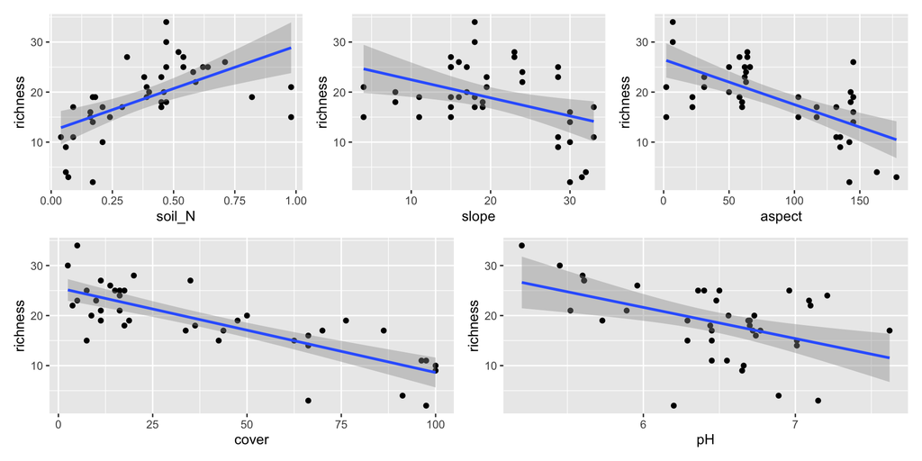

```r
w1 <- ggplot(data_washburn, aes(soil_N, richness)) +
  geom_point() +
  geom_smooth(method="lm")
  #scale_x_continuous(limits = c(0, 700))

w2 <- ggplot(data_washburn, aes(slope, richness)) +
  geom_point() +
  geom_smooth(method="lm")

w3 <- ggplot(data_washburn, aes(aspect, richness)) +
  geom_point() +
  geom_smooth(method="lm")

w4 <- ggplot(data_washburn, aes(cover, richness)) +
  geom_point() +
  geom_smooth(method="lm")

w5 <- ggplot(data_washburn, aes(pH, richness)) +
  geom_point() +
  geom_smooth(method="lm")

(w1 + w2 +w3) / (w4 + w5) #patchwork notation for figure alignment
```